# RepeatSoaker effect on DEGs detection

Using adapter trimmed, duplicates removed mouse RNA-seq data, we are investigating the biology of genes removed by RepeatSoaker. That is, What are the properties of the genes lost when removing reads overlapping low complexity regions.

First, we explore overlap among gene lists without RepeatSoaker treatment (remDup_all) and with RepeatSoaker treatment at different thresholds (remDup_75 - remDup_0)

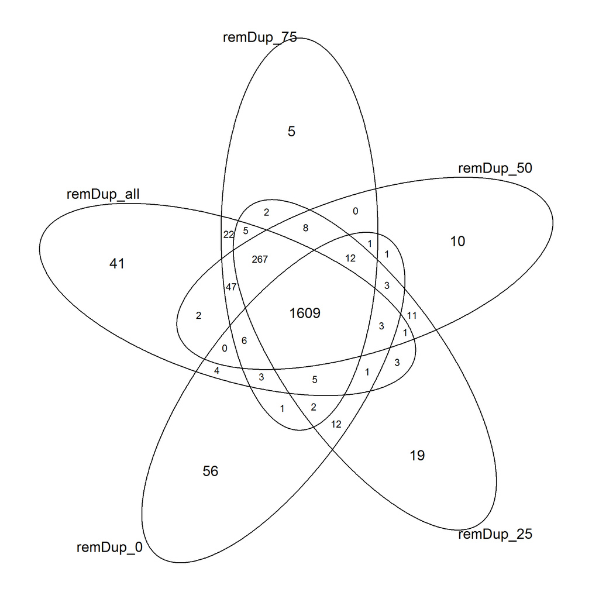

We observe that “RepeatSoaking” diminishes the number of differentially expressed genes. More rigorous soaking (less strict overlap threshold) also increases the number of genes not detected previously (the numbers in the “leaves” of the Venn diagram).

Withour RepeatSoaker, we have (all genes in the remDup_All oval):

```
## Number of differentially expressed PROBES, no RepeatSoaker: 2019
## Number of differentially expressed GENES, no RepeatSoaker: 1991
```

Some probes map to multiple genes, hence the discrepancy in counts of probes and genes.

After trimming the data with 0% RepeatSoaker settings, we have (remDup_0 oval):

```
## Number of differentially expressed PROBES, with RepeatSoaker: 1719
## Number of differentially expressed GENES, with RepeatSoaker: 1697
```

# Genes without vs. Genes with RepeatSoaker comparison

We compare enrichment analyses results using genes with and without reads overlapping low complexity regions (remDup_all vs. remDup_0).

## KEGG enrichment analysis without RepeatSoaker

[output not shown]

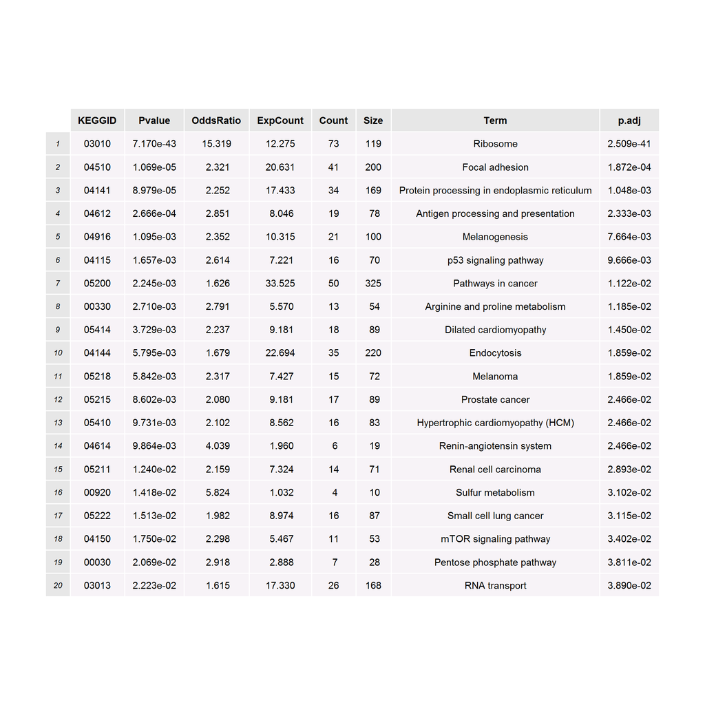

## KEGG enrichment analysis with RepeatSoaker

```
## The number of enriched KEGG :33
```

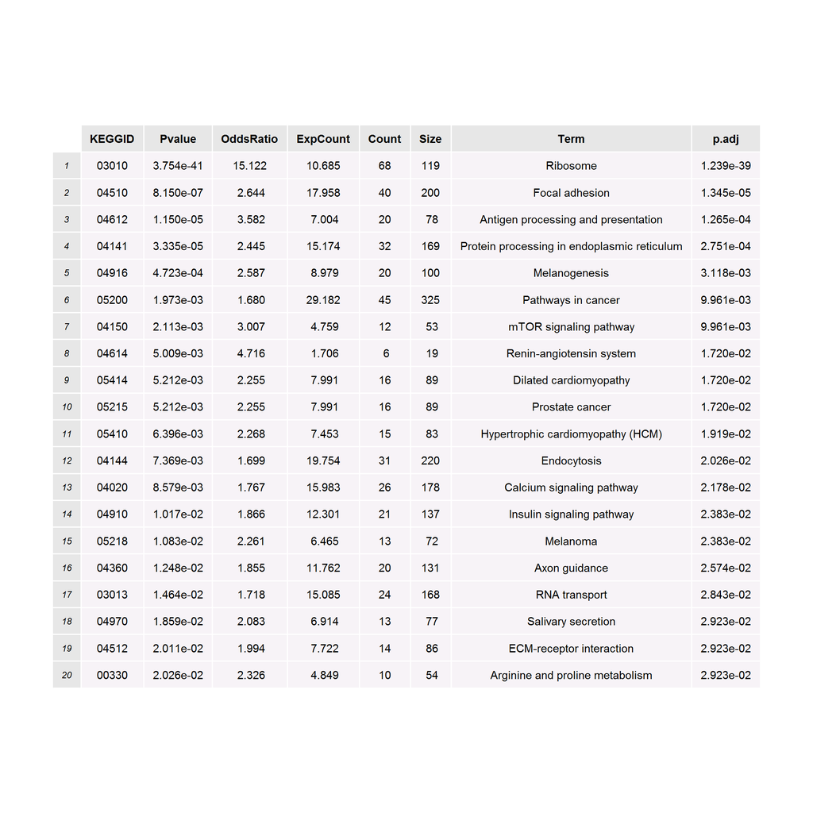

## GO enrichment analysis without RepeatSoaker

```
## The number of enriched GO :2035
```

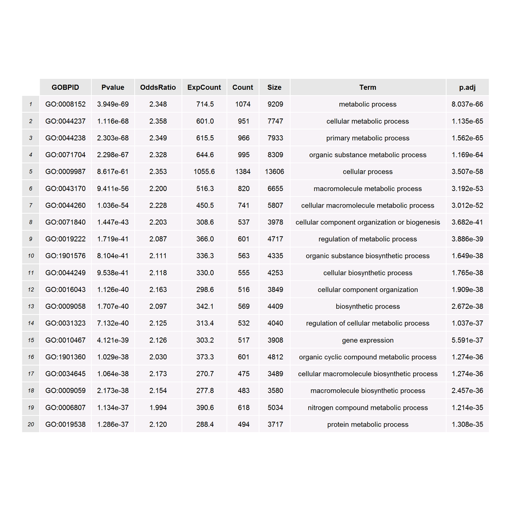

## GO enrichment analysis with RepeatSoaker

```
## The number of enriched GO :2025
```

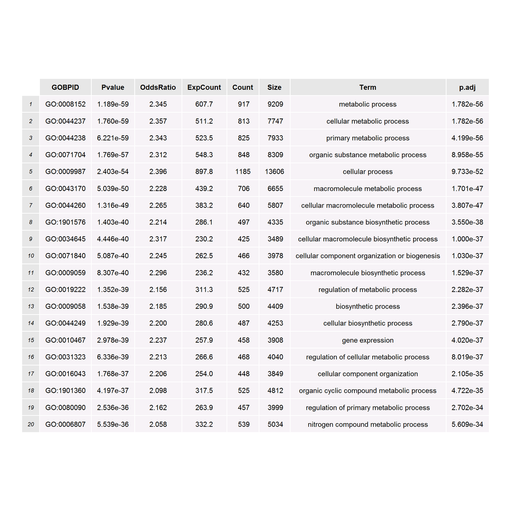

## Reactome enrichment analysis without RepeatSoaker

```
## The number of enriched Reactome pathways:403
```

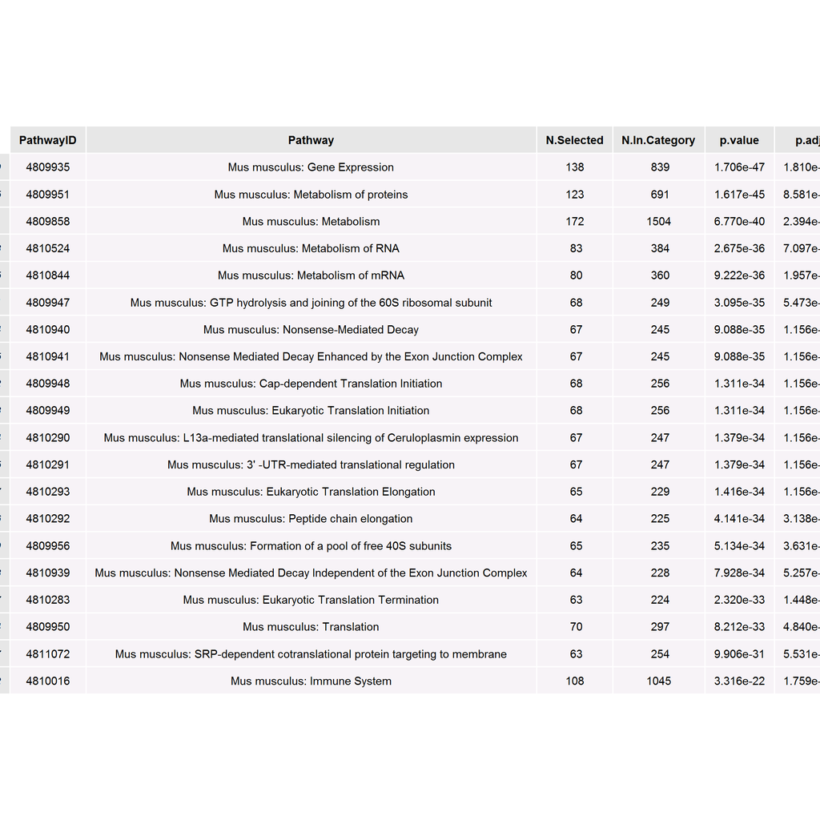

## Reactome enrichment analysis with RepeatSoaker

```
## The number of enriched Reactome pathways:390
```

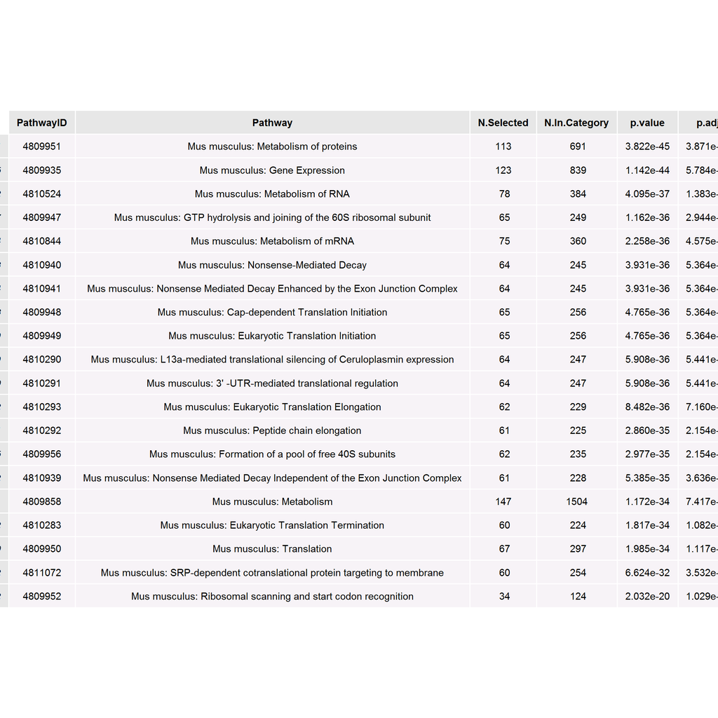

## Genes unique for different RepeatSoaker settings

Now, we check what those genes unique to each RepeatSoaker % are (leaves of the Venn diagram). We will look at:

1) Gene names and their description. Note that not all probes can be mapped to gene names, and some probes map to the same gene - therefore, the numbers in the Venn diagram and the tables below differ.

2) GO, KEGG and Reactome Pathway enrichment of those genes, if any.

## Unique genes without RepeatSoaker

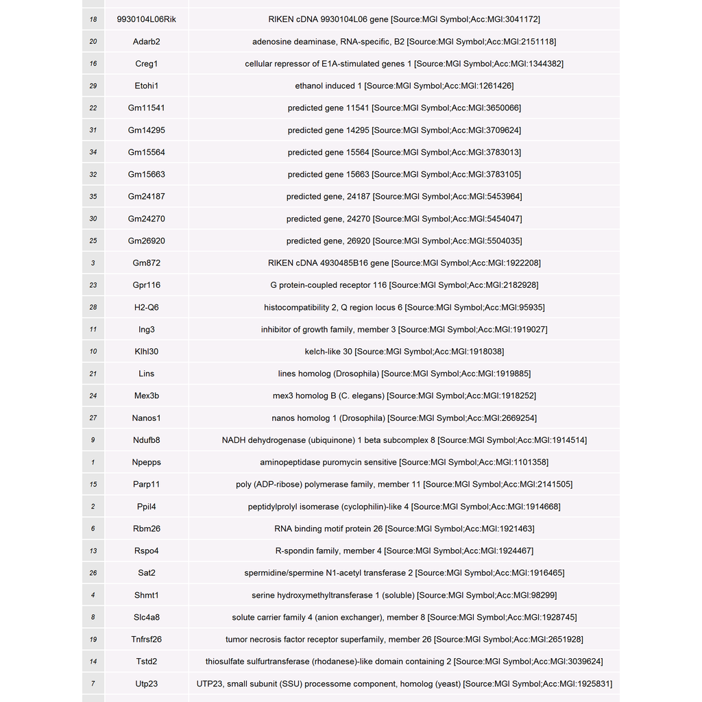

```
## The number of enriched KEGG :10
```

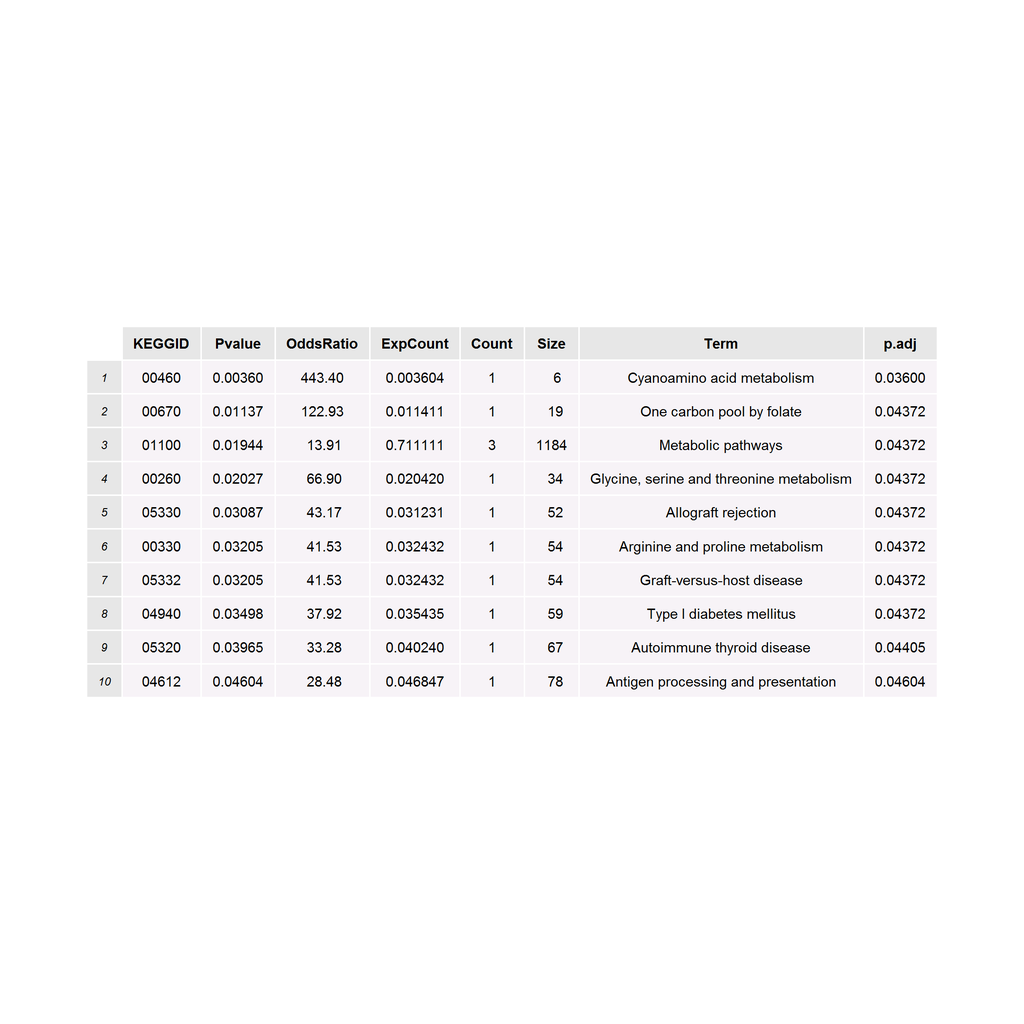

```
## The number of enriched GO :31
```

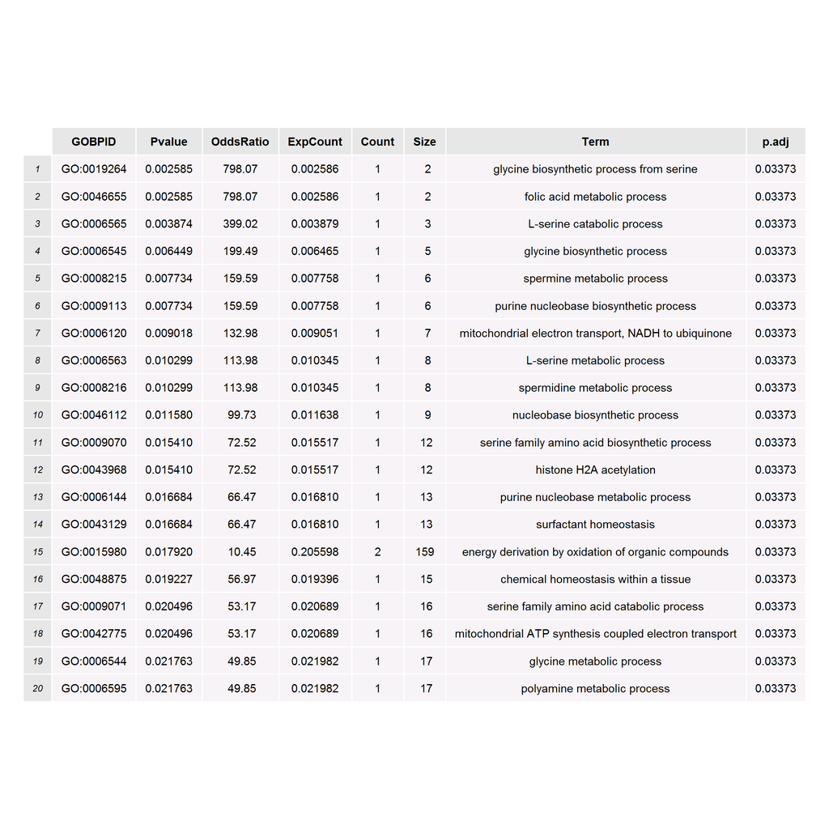

```
## The number of enriched Reactome pathways:0
```

## Unique genes with 75% RepeatSoaker

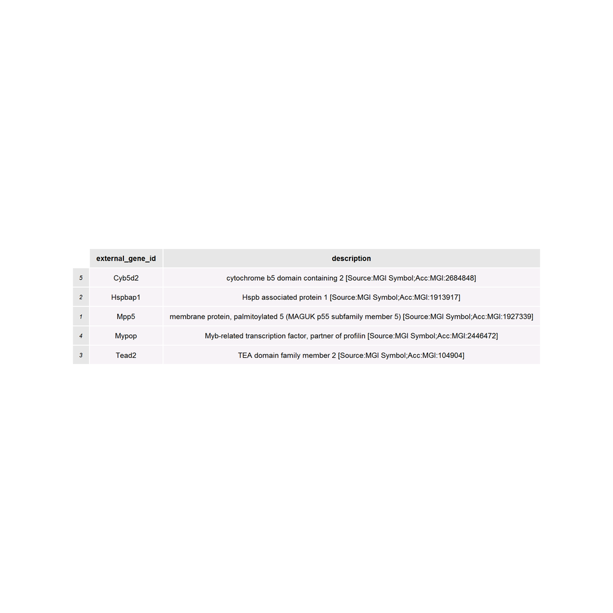

```
## The number of enriched KEGG :1
```

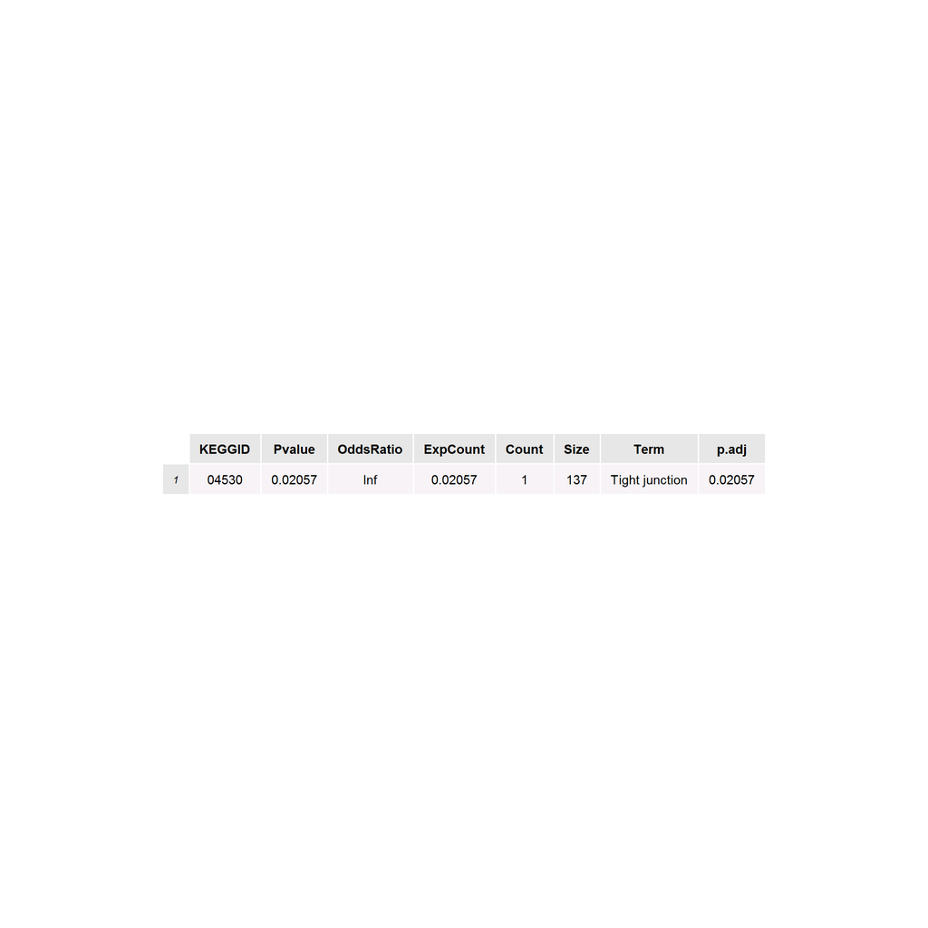

```
## The number of enriched GO :52
```

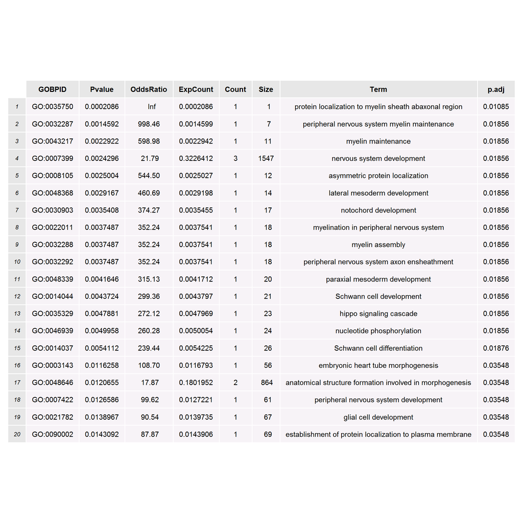

```
## The number of enriched Reactome pathways:6
```

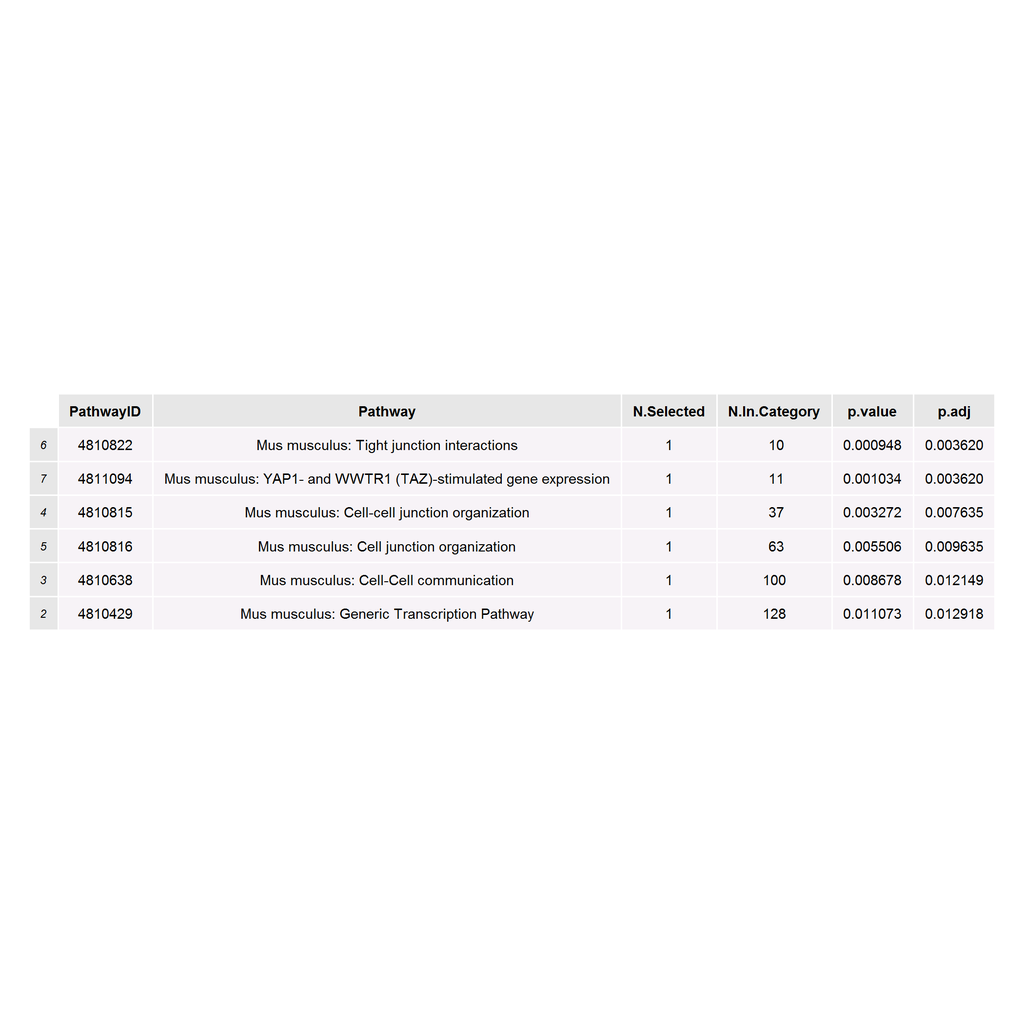

## Unique genes with 50% RepeatSoaker

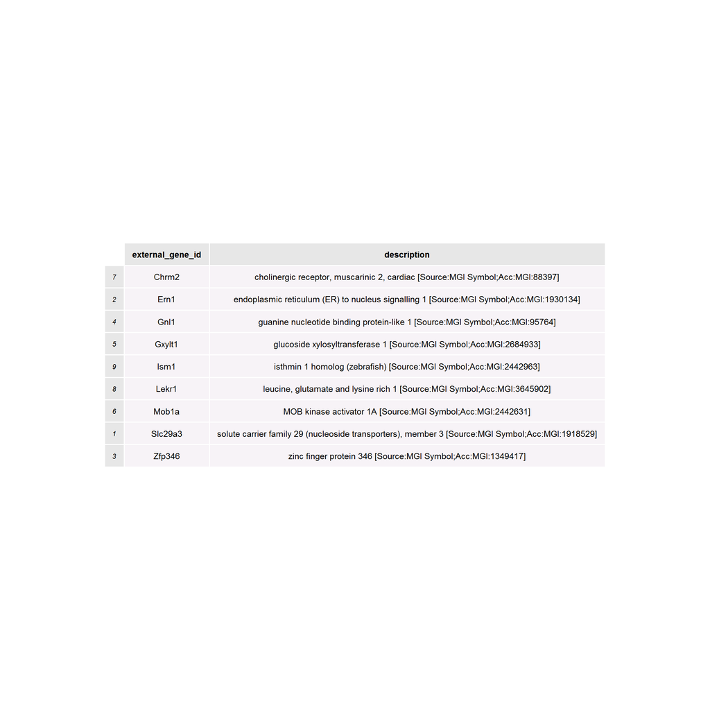

```
## The number of enriched KEGG :1
```

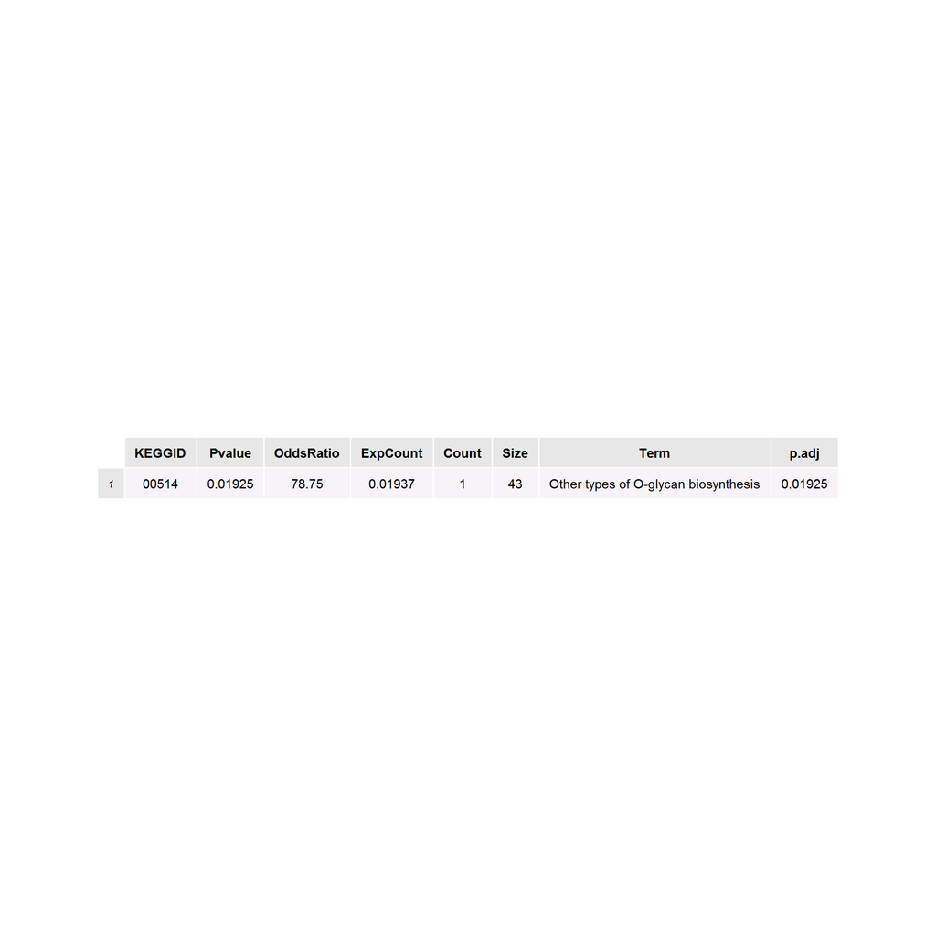

```
## The number of enriched GO :32
```

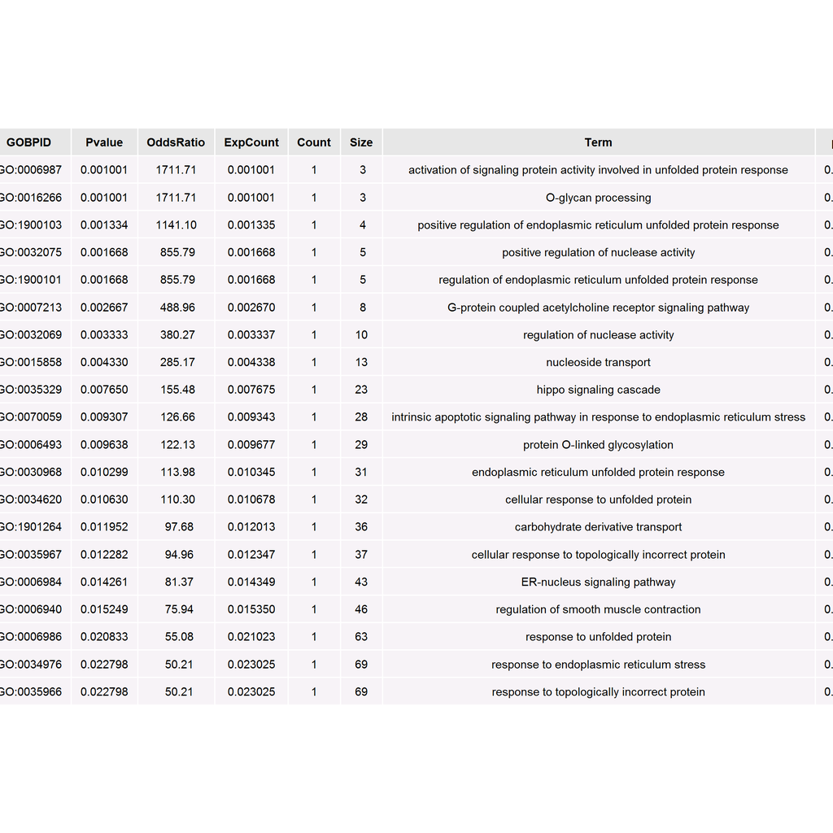

```
## The number of enriched Reactome pathways:25
```

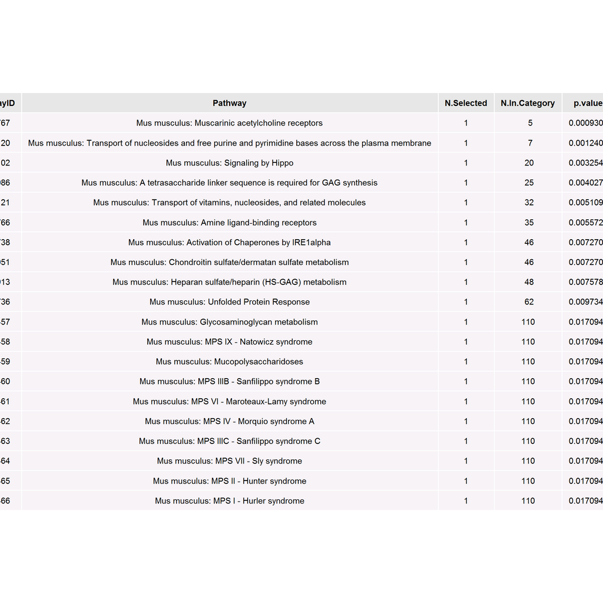

## Unique genes with 25% RepeatSoaker

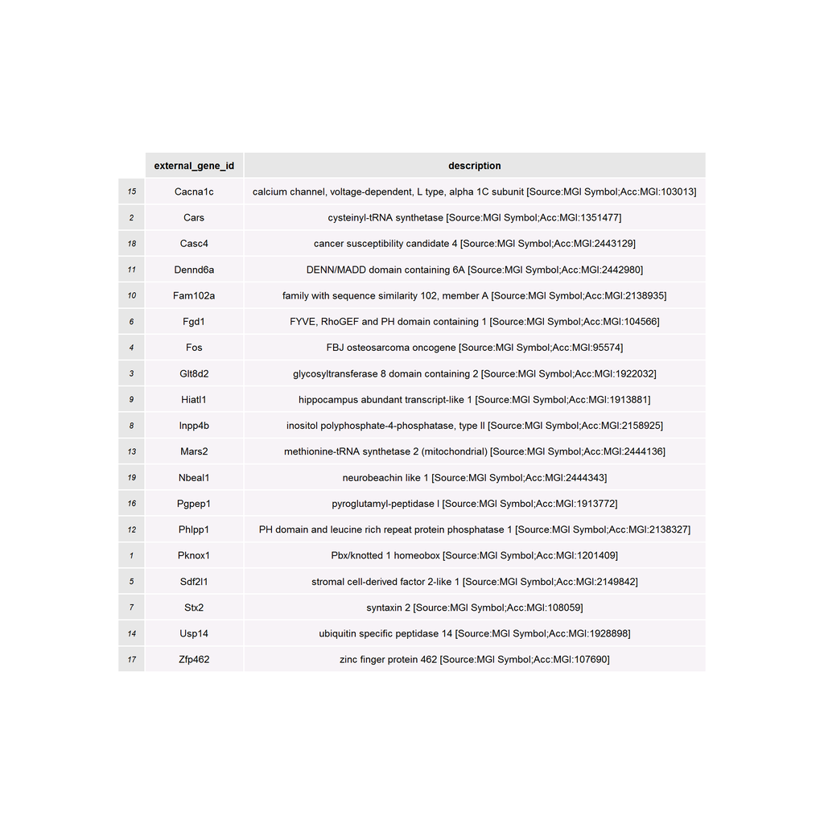

```
## The number of enriched KEGG :4
```

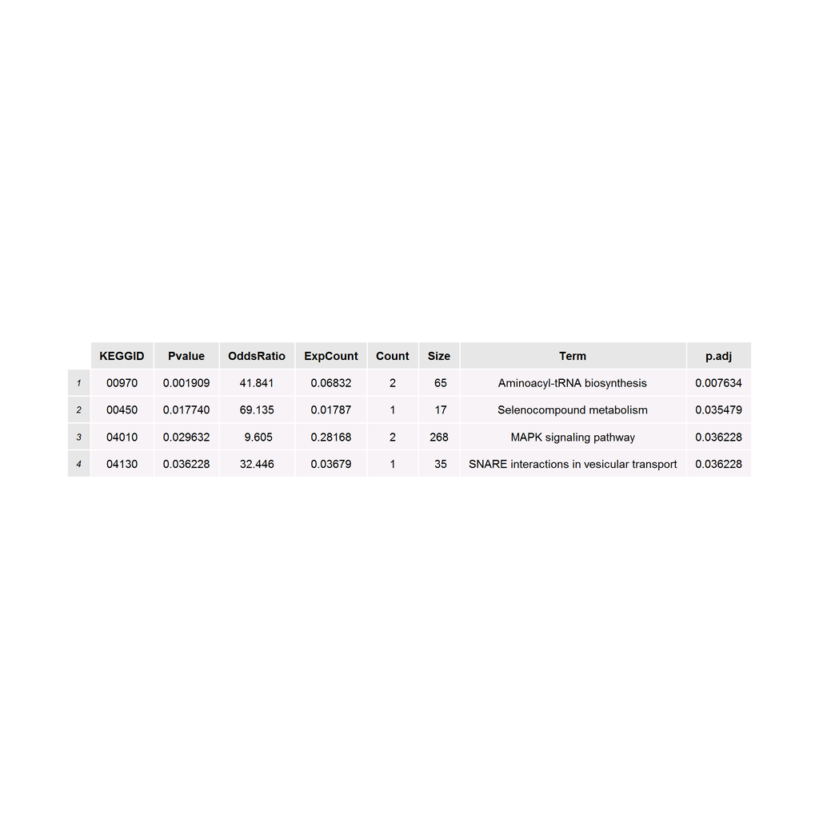

```
## The number of enriched GO :101
```

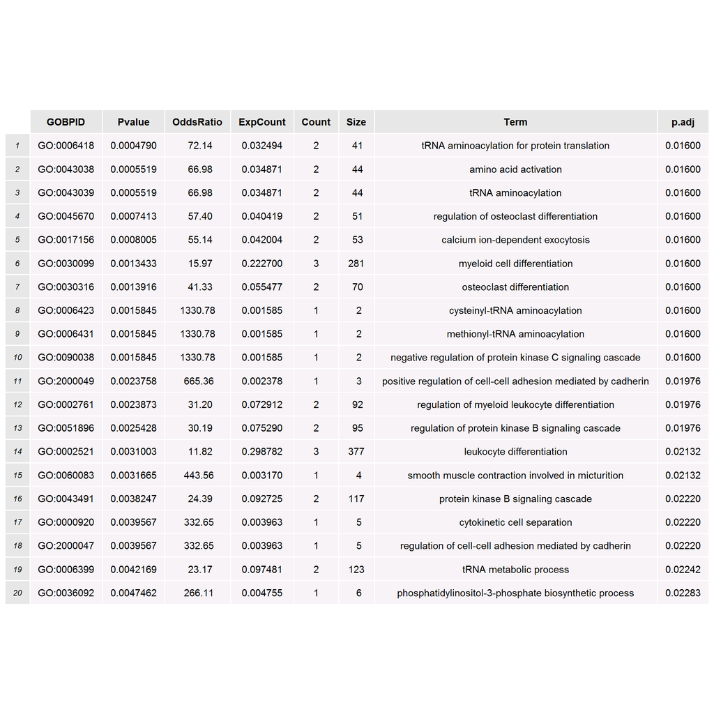

```
## The number of enriched Reactome pathways:51
```

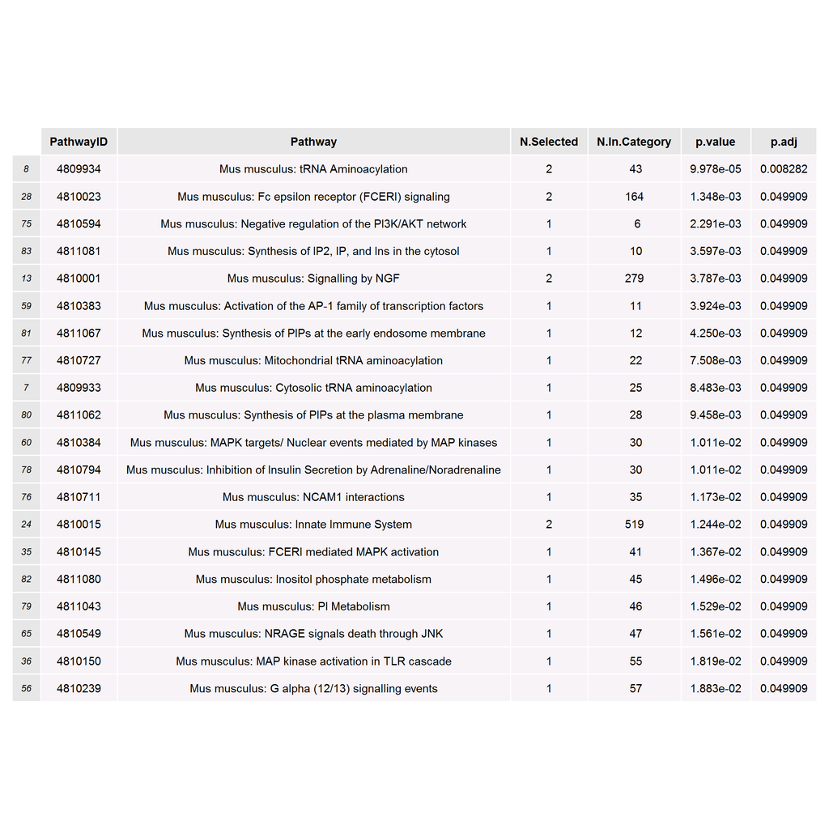

## Unique genes with 00% RepeatSoaker

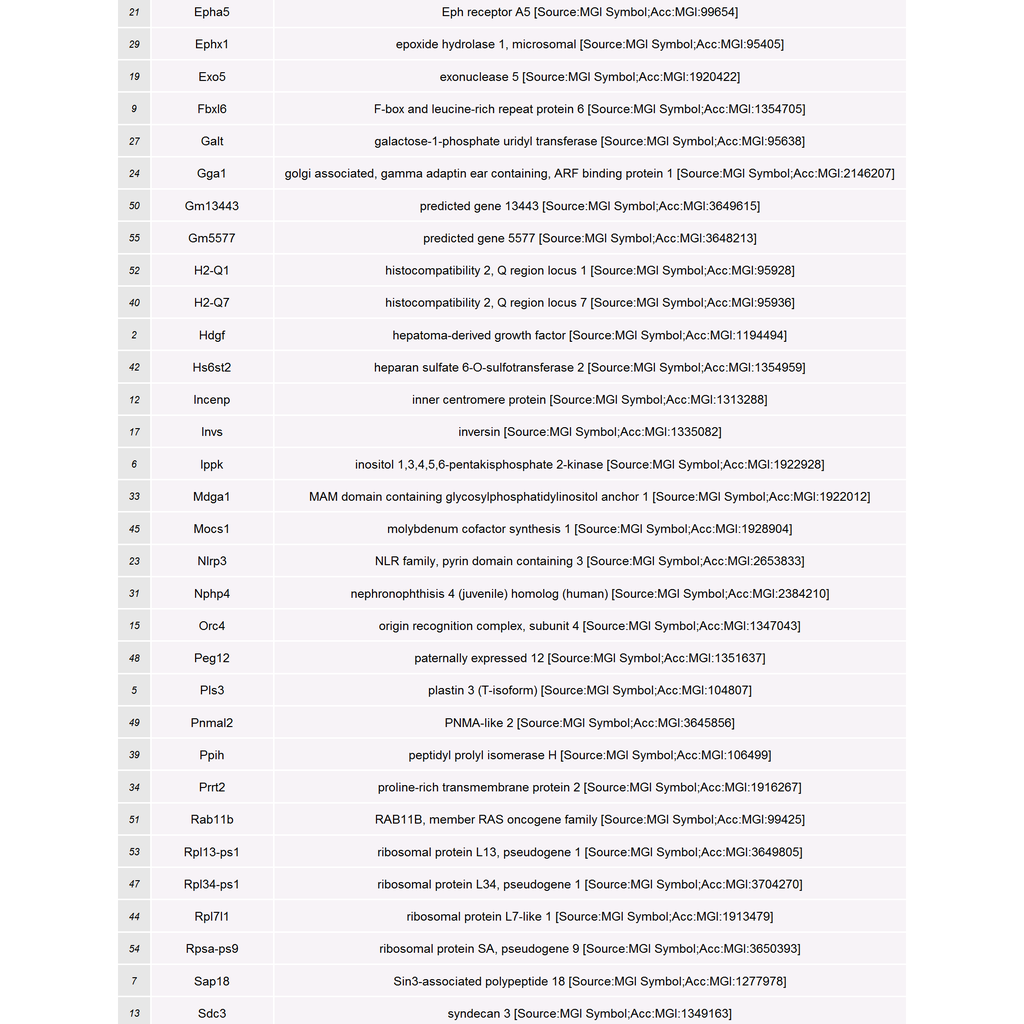

```
## The number of enriched KEGG :10
```

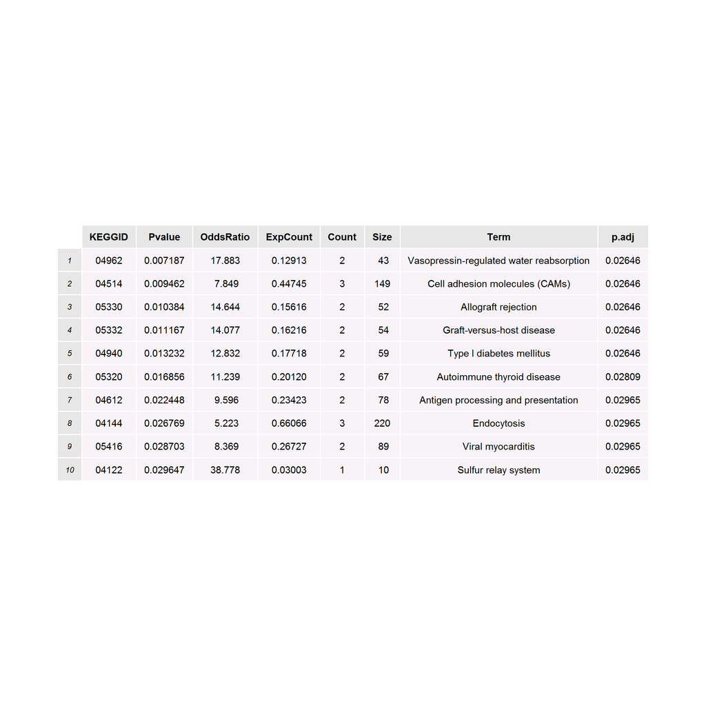

```
## The number of enriched GO :109
```

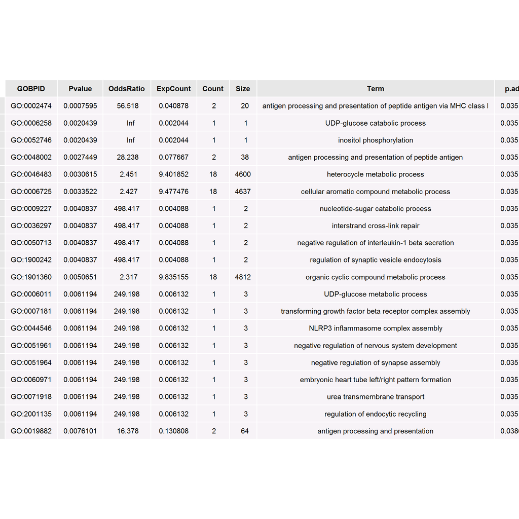

```
## The number of enriched Reactome pathways:43
```

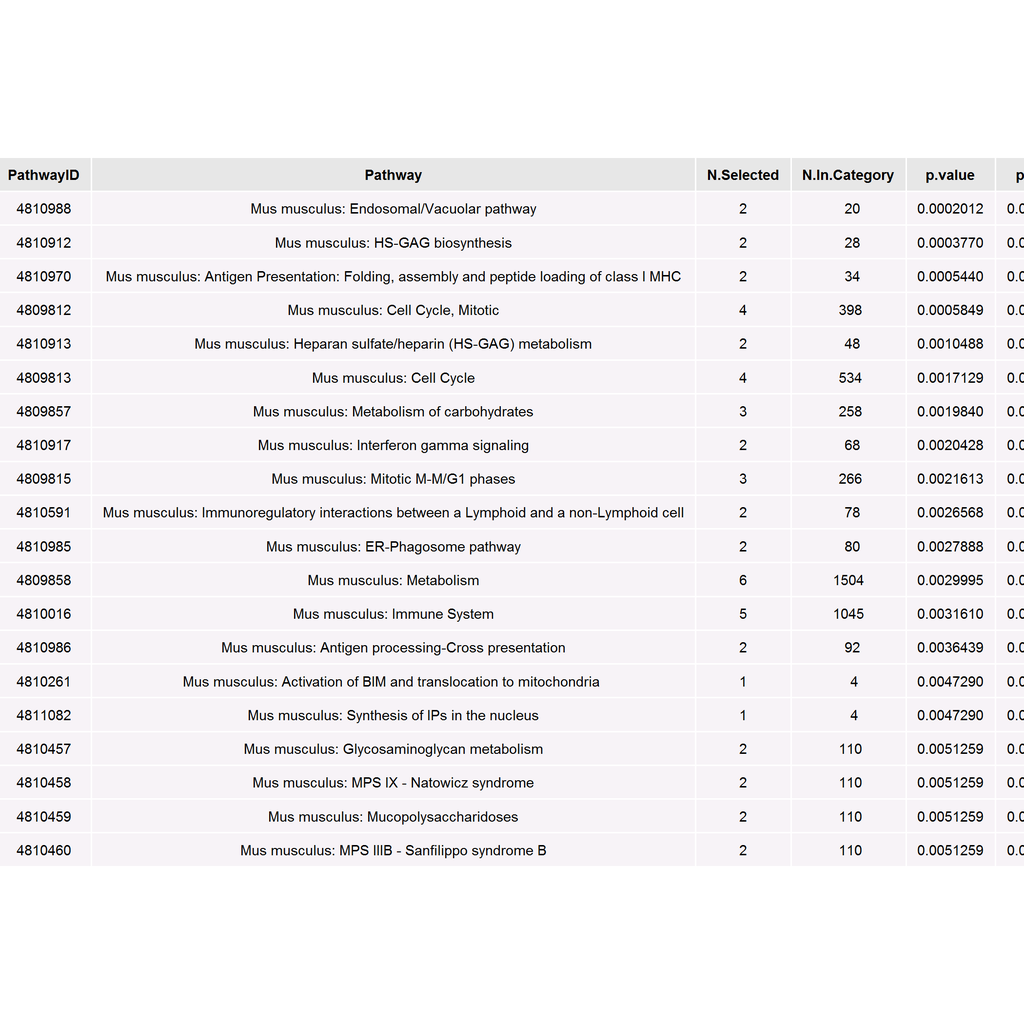

## Other tests

Let's have a look at the distribution of log2 fold change of genes in the leaves of the Venn diagram, as compared with that of the heart of the Venn diagram. It is expected that the leaves may have fold change different from the main DEGs.

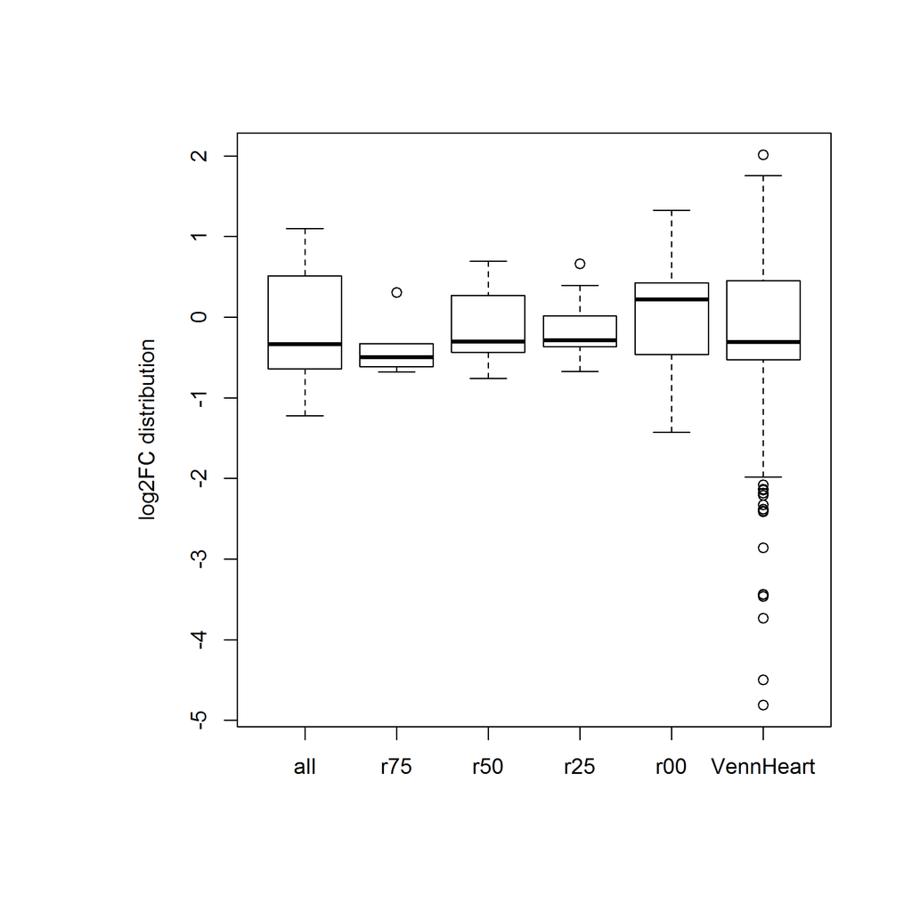

We also check the same for the expression level.

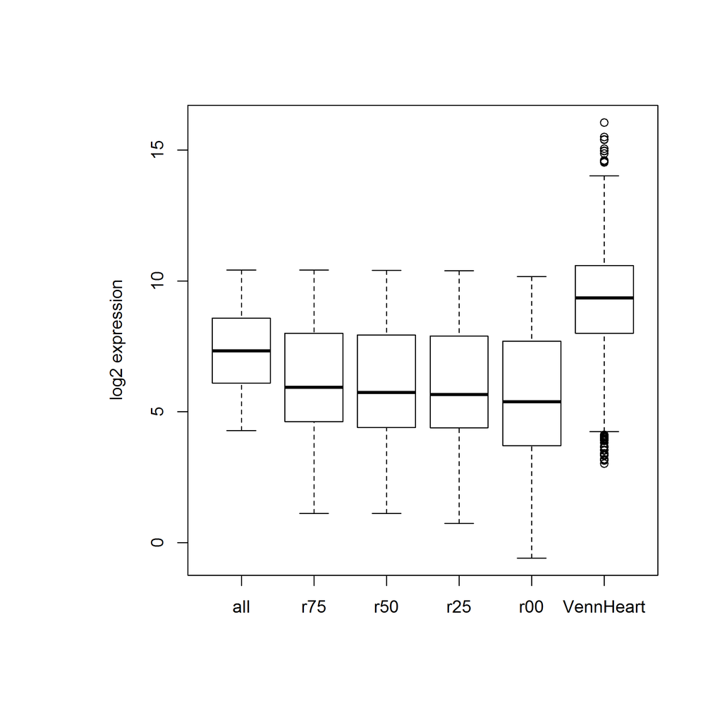

The leaves may have overall lower expression level, hence, more susceptible to the RepeatSoaker.